# Predicting errors in Unilateral Dumbbell Biceps Curl exercises

Marius Peche

22 July 2017

## Introduction and background

This project attempts to create a prediction model to decide if a particular exercise had been performed correctly, or if one of four common mistakes has occurred during the routine. Data has been sourced from http://groupware.les.inf.puc-rio.br/har, where six participants preformed 10 repetitions of the above mentioned exercise in five different ways, **Class A** being done correctly, and **class B** to **E** making a predefined common mistake during the exercise. Measuring devices such as accelerators were placed on four locations to record the movement and changes in orientation of the following regions: hips, arm, forearm and the dumbbell itself.

We will be using the *R* package *caret* for model building and creating data partitions for validations later on.

```r
library(caret)
```

## Initial Data analysis and preporcessing

### Loading and Splitting Data

We load the available data, and take a quick look at what the training set looks like. We also create a separate 20% partition for validation at the end of the project, since the supplied test set is to be used for the quiz.

```r
initial_training <- read.csv(file.path(getwd(),"pml-training.csv"))
initial_testing <- read.csv(file.path(getwd(),"pml-testing.csv"))
inTrain <- createDataPartition(y=initial_training$classe, p=0.80, list=FALSE)
training <- initial_training[inTrain,]
validate <- initial_training[-inTrain,]
str(training, vec.len=6, list.len=20)
```

```
## 'data.frame':    15699 obs. of  160 variables:
##  $ X                       : int  1 2 4 5 6 7 8 9 10 11 12 13 14 17 18 ...
##  $ user_name               : Factor w/ 6 levels "adelmo","carlitos",..: 2 2 2 2 2 2 2 2 2 2 2 2 2 2 2 ...
##  $ raw_timestamp_part_1    : int  1323084231 1323084231 1323084232 1323084232 1323084232 1323084232 1323084232 1323084232 1323084232 1323084232 1323084232 1323084232 1323084232 1323084232 1323084232 ...
##  $ raw_timestamp_part_2    : int  788290 808298 120339 196328 304277 368296 440390 484323 484434 500302 528316 560359 576390 692324 732306 ...
##  $ cvtd_timestamp          : Factor w/ 20 levels "02/12/2011 13:32",..: 9 9 9 9 9 9 9 9 9 9 9 9 9 9 9 ...
##  $ new_window              : Factor w/ 2 levels "no","yes": 1 1 1 1 1 1 1 1 1 1 1 1 1 1 1 ...
##  $ num_window              : int  11 11 12 12 12 12 12 12 12 12 12 12 12 12 12 ...
##  $ roll_belt               : num  1.41 1.41 1.48 1.48 1.45 1.42 1.42 1.43 1.45 1.45 1.43 1.42 1.42 1.51 1.55 ...
##  $ pitch_belt              : num  8.07 8.07 8.05 8.07 8.06 8.09 8.13 8.16 8.17 8.18 8.18 8.2 8.21 8.12 8.08 ...
##  $ yaw_belt                : num  -94.4 -94.4 -94.4 -94.4 -94.4 -94.4 -94.4 -94.4 -94.4 -94.4 -94.4 -94.4 -94.4 -94.4 -94.4 ...
##  $ total_accel_belt        : int  3 3 3 3 3 3 3 3 3 3 3 3 3 3 3 ...
##  $ kurtosis_roll_belt      : Factor w/ 397 levels "","-0.016850",..: 1 1 1 1 1 1 1 1 1 1 1 1 1 1 1 ...
##  $ kurtosis_picth_belt     : Factor w/ 317 levels "","-0.021887",..: 1 1 1 1 1 1 1 1 1 1 1 1 1 1 1 ...
##  $ kurtosis_yaw_belt       : Factor w/ 2 levels "","#DIV/0!": 1 1 1 1 1 1 1 1 1 1 1 1 1 1 1 ...
##  $ skewness_roll_belt      : Factor w/ 395 levels "","-0.003095",..: 1 1 1 1 1 1 1 1 1 1 1 1 1 1 1 ...
##  $ skewness_roll_belt.1    : Factor w/ 338 levels "","-0.005928",..: 1 1 1 1 1 1 1 1 1 1 1 1 1 1 1 ...
##  $ skewness_yaw_belt       : Factor w/ 2 levels "","#DIV/0!": 1 1 1 1 1 1 1 1 1 1 1 1 1 1 1 ...
##  $ max_roll_belt           : num  NA NA NA NA NA NA NA NA NA NA NA NA NA NA NA ...
##  $ max_picth_belt          : int  NA NA NA NA NA NA NA NA NA NA NA NA NA NA NA ...
##  $ max_yaw_belt            : Factor w/ 68 levels "","-0.1","-0.2",..: 1 1 1 1 1 1 1 1 1 1 1 1 1 1 1 ...
##   [list output truncated]
```

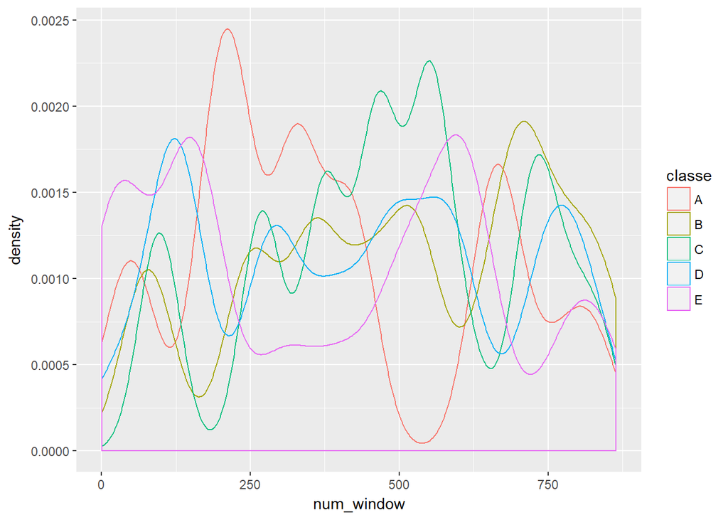

```r
investigate <- training[,which(names(training) %in%
      c("X","user_name","raw_timestamp_part_1","raw_timestamp_part_2",
        "cvtd_timestamp","new_window","num_window","classe"))]

library(ggplot2)
ggplot(investigate,aes(num_window,color=classe))+geom_density()
```

### Missing Values

We also see that there are columns with a lot of missing values, or values that is either blank or the error-message “#DIV/0!”. If these values are too numerous, we need to remove these columns as it won’t contribute anything to the final models.

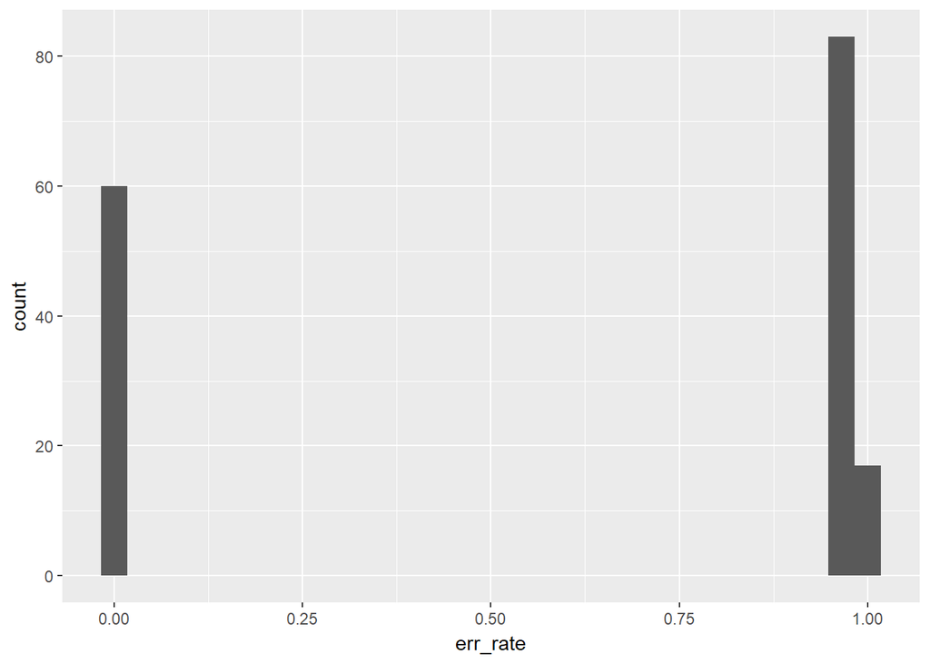

```r
calculate_null_freq <- function(na.freq) {
    for (a in seq_along(na.freq)) {
        #if
        if (!(is.na(na.freq[a])) && (na.freq[a] == "" || na.freq[a] == "#DIV/0!")){
            na.freq[a] = NA
        }
    }

    sum(is.na(na.freq))/length(na.freq)
}
index <- lapply(initial_training,calculate_null_freq)
ggplot(data.frame(column=names(index),err_rate=as.numeric(index)),aes(err_rate))+geom_histogram()
```

We find that data in a column is either mostly missing, or all present, therefore we remove the empty columns form our training set. This will reduce the number of predictor variables from 160 to 60

```r
training <- training[,index<0.2]
```

### Corrolated predictions

Hoping to reduce the number of predictors even further, we calculate the correlation between the remaining numeric values.

```r
corMatrix <- cor(training[,!(sapply(training,is.factor))])
diag(corMatrix) <- 0
which(corMatrix>0.8,arr.ind=TRUE)
```

```
##                  row col
## yaw_belt           7   5
## total_accel_belt   8   5
## accel_belt_y      13   5
## roll_belt          5   7
## roll_belt          5   8
## accel_belt_y      13   8
## magnet_belt_x     15  12
## roll_belt          5  13
## total_accel_belt   8  13
## accel_belt_x      12  15
## magnet_arm_x      28  25
## accel_arm_x       25  28
## magnet_arm_z      30  29
## magnet_arm_y      29  30
## accel_dumbbell_x  38  32
## accel_dumbbell_z  40  33
## gyros_forearm_z   50  37
## pitch_dumbbell    32  38
## yaw_dumbbell      33  40
## gyros_forearm_z   50  49
## gyros_dumbbell_z  37  50
## gyros_forearm_y   49  50
```

Though not very clear, it does appear that there may be some correlation between the values of the different regions, therefore we will focus our modeling in that direction.

## Attempt 1: Principal Companent Analysis for a single prediction model.

### Description

The first model we will attempt to create involves reducing the predictions for each region separately, using Principal Component Analysis. Thereafter, we combine all the data again and train our model, using the default caret libraries. We will also use k-fold cross validation with 10 folds to perfect our random forest.

### Process

```r
names(training[,grep("belt",names(training))])
```

```
##  [1] "roll_belt"        "pitch_belt"       "yaw_belt"
##  [4] "total_accel_belt" "gyros_belt_x"     "gyros_belt_y"
##  [7] "gyros_belt_z"     "accel_belt_x"     "accel_belt_y"
## [10] "accel_belt_z"     "magnet_belt_x"    "magnet_belt_y"
## [13] "magnet_belt_z"
```

Looking at the names of the columns for, say, the belt we can identify around 4 associated measurements: Euler angles (pitch, roll, yaw), magnet, accelerate, gyros. Therefore we will create 4 principal components for each region. Finally, we combine the principal components for these regions, along with the original result-variable into a new training set to be used for training the first model.

```r
belt_trainset <- training[,grep("belt",names(training))]
preProc_belt <- preProcess(belt_trainset, method="pca", pcaComp = 4)
belt_trainprep <- predict(preProc_belt,belt_trainset)

arm_trainset <- training[,grep("arm",names(training))]
preProc_arm <- preProcess(arm_trainset, method="pca", pcaComp = 4)
arm_trainprep <- predict(preProc_arm,arm_trainset)

forearm_trainset <- training[,grep("forearm",names(training))]
preProc_forearm <- preProcess(forearm_trainset, method="pca", pcaComp = 4)
forearm_trainprep <- predict(preProc_forearm,forearm_trainset)

dumbbell_trainset <- training[,grep("dumbbell",names(training))]
preProc_dumbell <- preProcess(dumbbell_trainset, method="pca", pcaComp = 4)
dumbbell_trainprep <- predict(preProc_dumbell,dumbbell_trainset)

model1_training <- data.frame(belt=belt_trainprep, arm=arm_trainprep, forearm=forearm_trainprep, dumbbell=dumbbell_trainprep,
                              classe=training[,which(names(training)=="classe")])

#create 10 k-fold cross validation
train_control <- trainControl(method="cv", number=10)
model1 <- train(classe ~ ., model1_training, trControl=train_control)
```

Printing out the details of the first model, we find that the accuracy is reported as 0.9689786

## Attempt 2: Model stacking.

### Description

Stacking several models have always increased the prediction power. It will be worth while to investigate the results of creating prediction models for each region separately, and then to pool their results together in a final prediction model. Again, we will use the default settings provided by the caret library to train our models, and again we will also use k-fold cross validation with 10 folds to perfect our random forest.

### Process

```r
belt_trainset["classe"] <- training["classe"]
belt_model <- train(classe ~ ., belt_trainset, trControl=train_control)
belt_predict_train <- predict(belt_model, newdata = belt_trainset)

arm_trainset["classe"] <- training["classe"]
arm_model <- train(classe ~ ., arm_trainset, trControl=train_control)
arm_predict_train <- predict(arm_model, newdata = arm_trainset)

forearm_trainset["classe"] <- training["classe"]
forearm_model <- train(classe ~ ., forearm_trainset, trControl=train_control)
forearm_predict_train <- predict(forearm_model, newdata = forearm_trainset)

dumbbell_trainset["classe"] <- training["classe"]
dumbbell_model <- train(classe ~ ., dumbbell_trainset, trControl=train_control)
dumbbell_predict_train <- predict(dumbbell_model, newdata = dumbbell_trainset)

model2_training <- data.frame(belt=belt_predict_train, arm=arm_predict_train, forearm=forearm_predict_train, dumbbell=dumbbell_predict_train,
                              classe=training[,which(names(training)=="classe")])

model2 <- train(classe ~ ., model2_training, trControl=train_control)
```

Printing out the details of the these models, we find that the individually, the accuracy is reported as between 0.8941309 and 0.9737562, with the final model reporting an accuracy of 1. This suggest over-fitting, which is the main reason for the proper validation set we created earlier on.

## Final validation of the two models.

We process the validation set in the same manner as the training set, using the created models, and attempt to predict their classes using both models described above.

```r
validate <- validate[,index<0.2]
belt_testset <- validate[,grep("belt",names(validate))]
belt_testprep <- predict(preProc_belt,belt_testset)

arm_testset <- validate[,grep("arm",names(validate))]
arm_testprep <- predict(preProc_arm,arm_testset)

forearm_testset <- validate[,grep("forearm",names(validate))]
forearm_testprep <- predict(preProc_forearm,forearm_testset)

dumbbell_testset <- validate[,grep("dumbbell",names(validate))]
dumbbell_testprep <- predict(preProc_dumbell,dumbbell_testset)

model1_testing <- data.frame(belt=belt_testprep, arm=arm_testprep, forearm=forearm_testprep, dumbbell=dumbbell_testprep,
                             classe=validate$class)

model1_results <- predict(model1,newdata = model1_testing)
conf1 <- confusionMatrix(model1_results,model1_testing$classe)
conf1$overall["Accuracy"]
```

```
##  Accuracy
## 0.9732348
```

```r
###model2
belt_predict_test <- predict(belt_model, newdata = belt_testset)
arm_predict_test <- predict(arm_model, newdata = arm_testset)
forearm_predict_test <- predict(forearm_model, newdata = forearm_testset)
dumbbell_predict_test <- predict(dumbbell_model, newdata = dumbbell_testset)
model2_testing <- data.frame(belt=belt_predict_test, arm=arm_predict_test, forearm=forearm_predict_test, dumbbell=dumbbell_predict_test,
                             classe=validate$classe)

model2_results <- predict(model2,newdata = model2_testing)
conf2 <- confusionMatrix(model2_results,model2_testing$classe)
conf2$overall["Accuracy"]
```

```
##  Accuracy
## 0.9683915
```

## Conclusion

Though not described in this report, the results of *Linear discriminant analysis* reports have also been considered and found to perform much worse than the default *Random forests* offered by the **caret** library. *Naive Beyas* predictions were specifically not investigated, as the whole approach of this study revolved around the dependence between the measurements.

We found that the first approach resulted in an expected out-of-sample error rate of 2.6765231%, while the second approach actually did slightly worse at 3.1608463%.

## Citations

The data has been obtained form the following source: *Velloso, E.; Bulling, A.; Gellersen, H.;??Ugulino, W.;??Fuks, H.??Qualitative Activity Recognition of Weight Lifting Exercises. Proceedings of 4th International Conference in Cooperation with SIGCHI (Augmented Human ’13) . Stuttgart, Germany: ACM SIGCHI, 2013.*